# Experiments with groups of stations: using kmeans for 3 clusters with lake_perc and fpg as params

FBK

9 januar 2017

```
## [1] "st_selection_1"
```

```
##  [1]   1  10  11  12  13  16  17  18  20  21  25  27  34  38  39  40  42
## [18]  43  46  49  50  56  57  77 111 116 117 119 121 122 123 124 144 149
## [35] 150 152 153 160 161 166 168 174 180 188 189 202 203 208 214 222 224
## [52] 229 230 231 233 234 235 237 240 242 244 245 246 247 251 252 254 256
## [69] 289 298
```

```
## [1] "st_selection_2"
```

```
##  [1]  14  15  19  22  23  28  29  31  32  41  44  45  59  60  61  62  63
## [18]  65  66  67  69  74  91  92  96  97 102 103 105 107 108 109 110 112
## [35] 120 125 126 127 128 133 136 138 140 141 142 157 163 164 165 171 175
## [52] 179 182 197 201 204 216 227 262 279 288 290 291
```

```
## [1] "st_selection_3"
```

```
##  [1]  33  58  64  68  75  78  80  81  82  83  84  85  88  93  94 106 130
## [18] 132 134 145 147 156 176 185 220 283
```

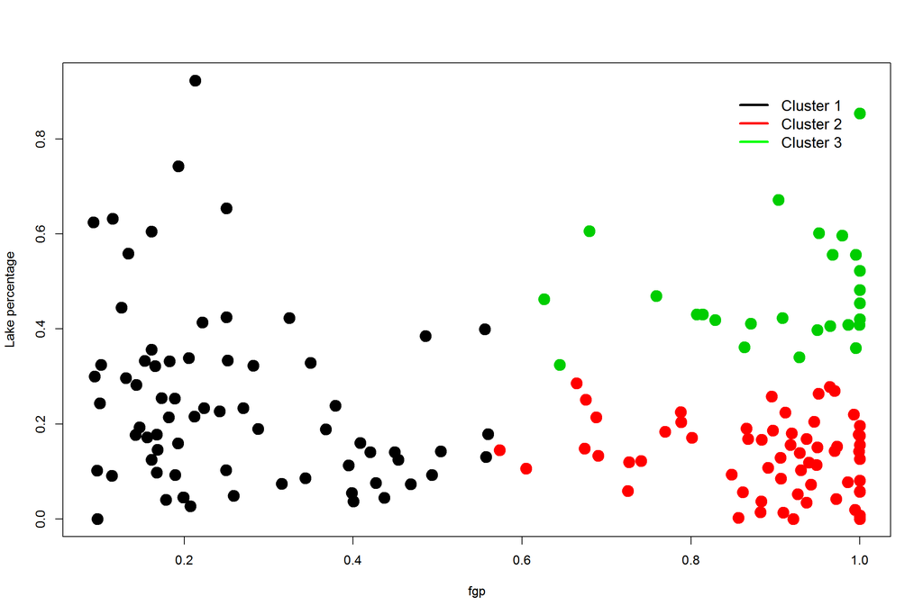

## QS

[1] “QS” [1] 2 [1] 1 10 11 12 13 16 17 18 20 21 25 27 34 38 39 40 42 [18] 43 46 49 50 56 57 77 111 116 117 119 121 122 123 124 144 149 [35] 150 152 153 160 161 166 168 174 180 188 189 202 203 208 214 222 224 [52] 229 230 231 233 234 235 237 240 242 244 245 246 247 251 252 254 256 [69] 289 298 [1] “done printint”

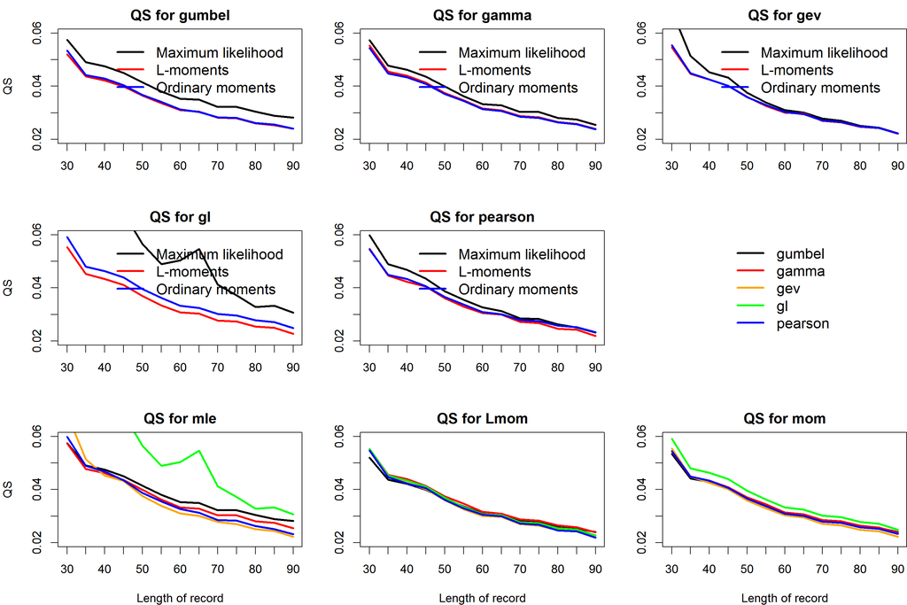

[1] “QS” [1] 2 [1] 14 15 19 22 23 28 29 31 32 41 44 45 59 60 61 62 63 [18] 65 66 67 69 74 91 92 96 97 102 103 105 107 108 109 110 112 [35] 120 125 126 127 128 133 136 138 140 141 142 157 163 164 165 171 175 [52] 179 182 197 201 204 216 227 262 279 288 290 291 [1] “done printint”

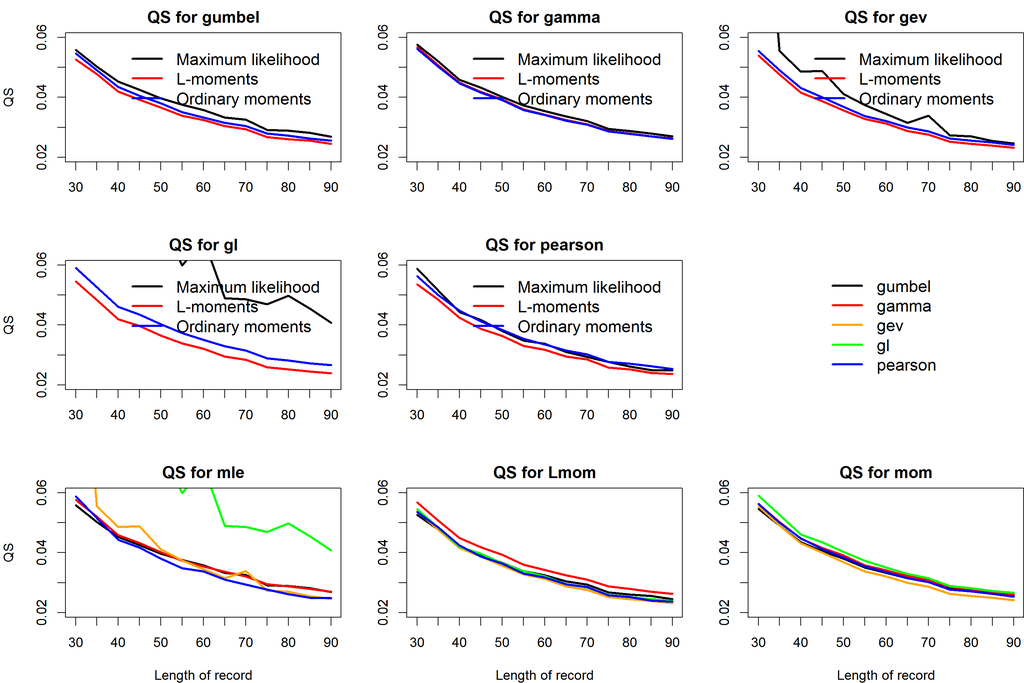

[1] “QS” [1] 2 [1] 33 58 64 68 75 78 80 81 82 83 84 85 88 93 94 106 130 [18] 132 134 145 147 156 176 185 220 283 [1] “done printint”

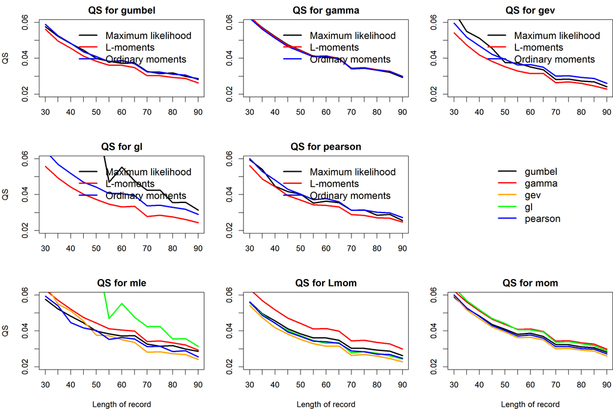

## BS

[1] “BS” [1] 2 [1] 1 10 11 12 13 16 17 18 20 21 25 27 34 38 39 40 42 [18] 43 46 49 50 56 57 77 111 116 117 119 121 122 123 124 144 149 [35] 150 152 153 160 161 166 168 174 180 188 189 202 203 208 214 222 224 [52] 229 230 231 233 234 235 237 240 242 244 245 246 247 251 252 254 256 [69] 289 298 [1] “done printint”

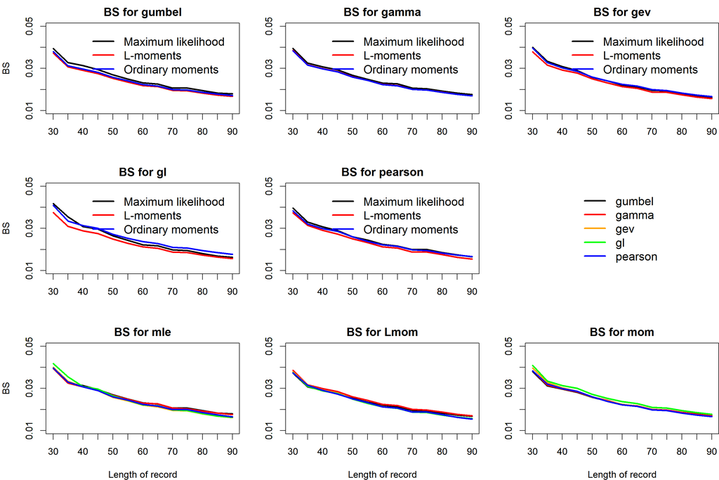

[1] “BS” [1] 2 [1] 14 15 19 22 23 28 29 31 32 41 44 45 59 60 61 62 63 [18] 65 66 67 69 74 91 92 96 97 102 103 105 107 108 109 110 112 [35] 120 125 126 127 128 133 136 138 140 141 142 157 163 164 165 171 175 [52] 179 182 197 201 204 216 227 262 279 288 290 291 [1] “done printint”

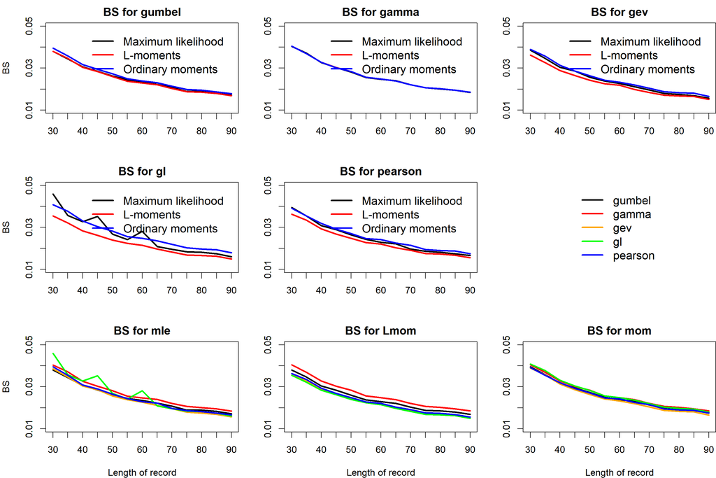

[1] “BS” [1] 2 [1] 33 58 64 68 75 78 80 81 82 83 84 85 88 93 94 106 130 [18] 132 134 145 147 156 176 185 220 283 [1] “done printint”

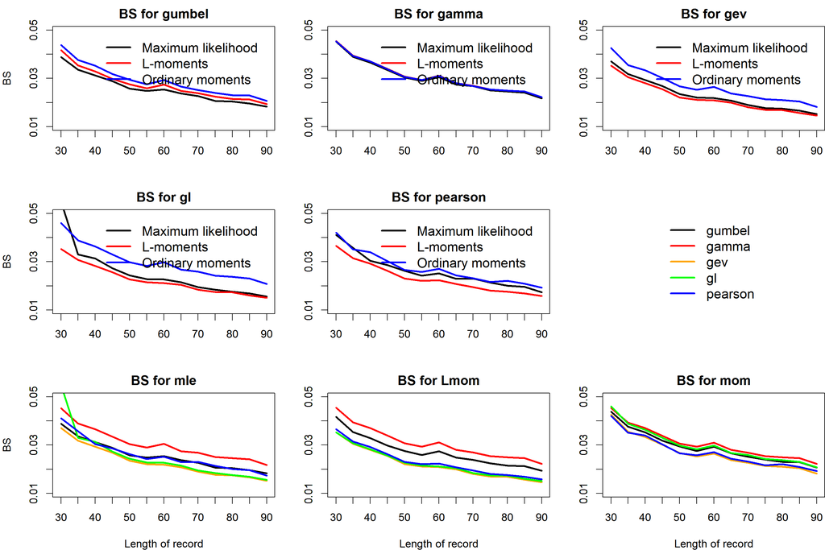

## Return levels

#### RL 10y

[1] “r.levels” [1] 10 [1] 1 10 11 12 13 16 17 18 20 21 25 27 34 38 39 40 42 [18] 43 46 49 50 56 57 77 111 116 117 119 121 122 123 124 144 149 [35] 150 152 153 160 161 166 168 174 180 188 189 202 203 208 214 222 224 [52] 229 230 231 233 234 235 237 240 242 244 245 246 247 251 252 254 256 [69] 289 298 [1] “done printint”

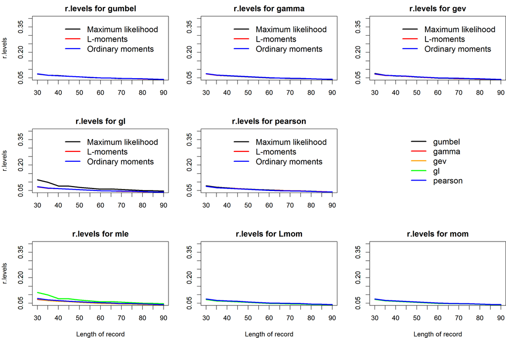

[1] “r.levels” [1] 10 [1] 14 15 19 22 23 28 29 31 32 41 44 45 59 60 61 62 63 [18] 65 66 67 69 74 91 92 96 97 102 103 105 107 108 109 110 112 [35] 120 125 126 127 128 133 136 138 140 141 142 157 163 164 165 171 175 [52] 179 182 197 201 204 216 227 262 279 288 290 291 [1] “done printint”

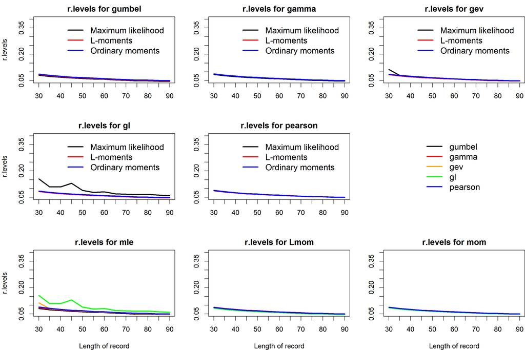

[1] “r.levels” [1] 10 [1] 33 58 64 68 75 78 80 81 82 83 84 85 88 93 94 106 130 [18] 132 134 145 147 156 176 185 220 283 [1] “done printint”

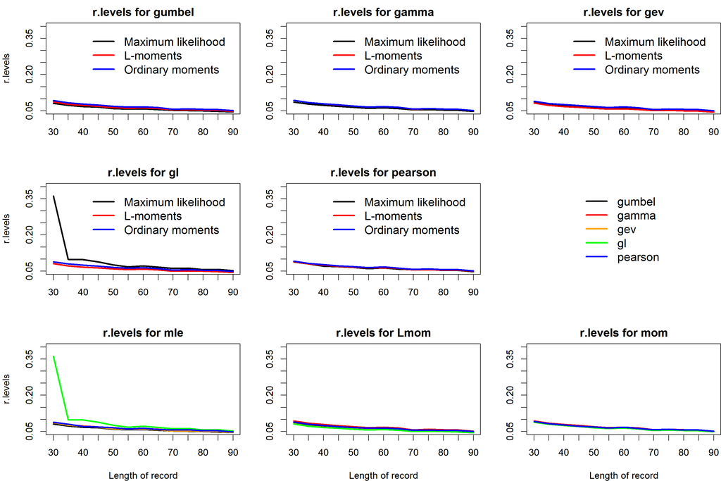

#### RL 100y

[1] “r.levels” [1] 100 [1] 1 10 11 12 13 16 17 18 20 21 25 27 34 38 39 40 42 [18] 43 46 49 50 56 57 77 111 116 117 119 121 122 123 124 144 149 [35] 150 152 153 160 161 166 168 174 180 188 189 202 203 208 214 222 224 [52] 229 230 231 233 234 235 237 240 242 244 245 246 247 251 252 254 256 [69] 289 298 [1] “done printint”

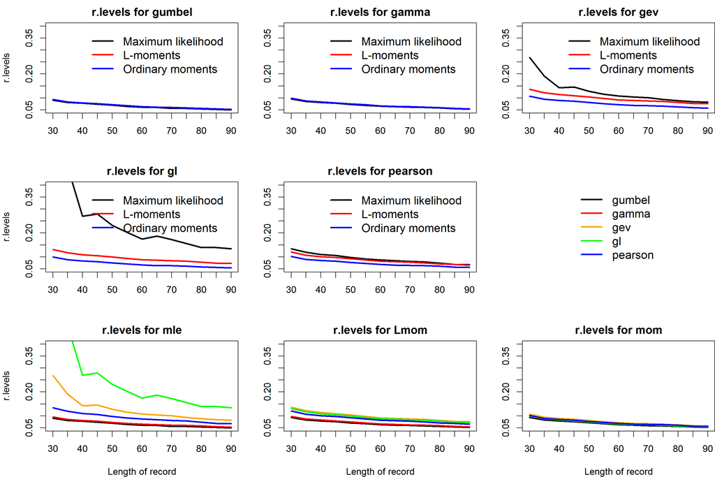

[1] “r.levels” [1] 100 [1] 14 15 19 22 23 28 29 31 32 41 44 45 59 60 61 62 63 [18] 65 66 67 69 74 91 92 96 97 102 103 105 107 108 109 110 112 [35] 120 125 126 127 128 133 136 138 140 141 142 157 163 164 165 171 175 [52] 179 182 197 201 204 216 227 262 279 288 290 291 [1] “done printint”

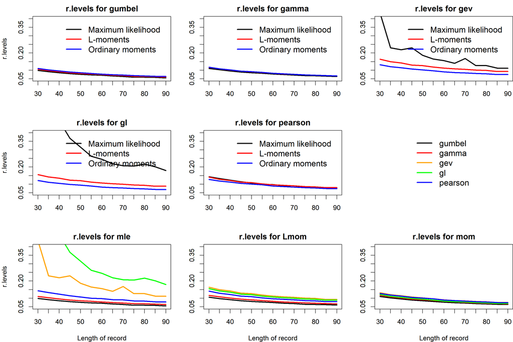

[1] “r.levels” [1] 100 [1] 33 58 64 68 75 78 80 81 82 83 84 85 88 93 94 106 130 [18] 132 134 145 147 156 176 185 220 283 [1] “done printint”

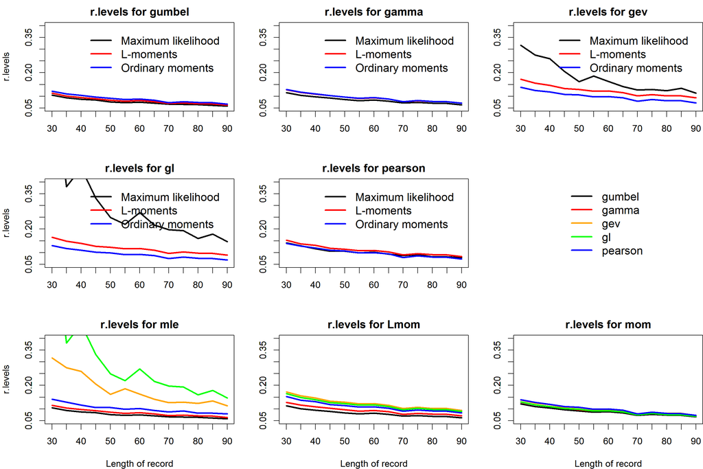

#### RL 200y

[1] “r.levels” [1] 200 [1] 1 10 11 12 13 16 17 18 20 21 25 27 34 38 39 40 42 [18] 43 46 49 50 56 57 77 111 116 117 119 121 122 123 124 144 149 [35] 150 152 153 160 161 166 168 174 180 188 189 202 203 208 214 222 224 [52] 229 230 231 233 234 235 237 240 242 244 245 246 247 251 252 254 256 [69] 289 298 [1] “done printint”

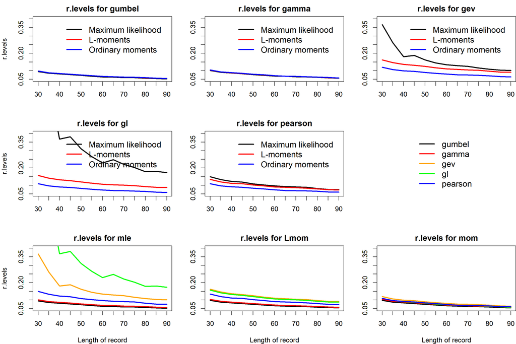

[1] “r.levels” [1] 200 [1] 14 15 19 22 23 28 29 31 32 41 44 45 59 60 61 62 63 [18] 65 66 67 69 74 91 92 96 97 102 103 105 107 108 109 110 112 [35] 120 125 126 127 128 133 136 138 140 141 142 157 163 164 165 171 175 [52] 179 182 197 201 204 216 227 262 279 288 290 291 [1] “done printint”

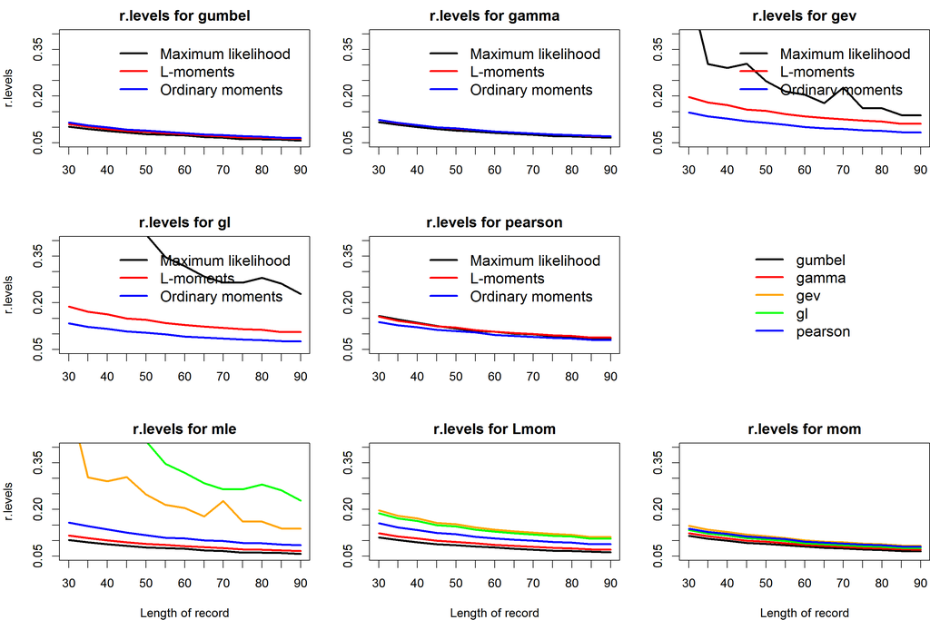

[1] “r.levels” [1] 200 [1] 33 58 64 68 75 78 80 81 82 83 84 85 88 93 94 106 130 [18] 132 134 145 147 156 176 185 220 283 [1] “done printint”

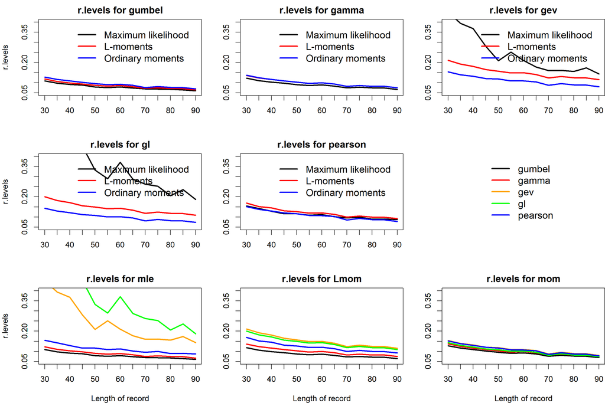

## KS

[1] 1 10 11 12 13 16 17 18 20 21 25 27 34 38 39 40 42 [18] 43 46 49 50 56 57 77 111 116 117 119 121 122 123 124 144 149 [35] 150 152 153 160 161 166 168 174 180 188 189 202 203 208 214 222 224 [52] 229 230 231 233 234 235 237 240 242 244 245 246 247 251 252 254 256 [69] 289 298 [1] “entered the plotting function” [1] 30 [1] 150

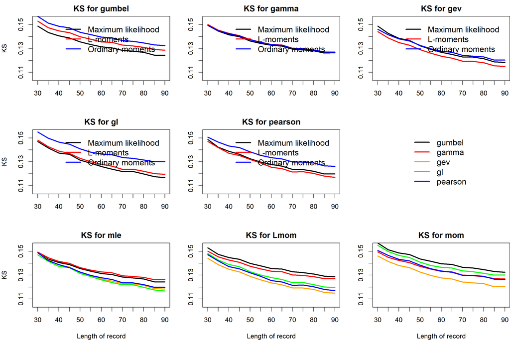

[1] 14 15 19 22 23 28 29 31 32 41 44 45 59 60 61 62 63 [18] 65 66 67 69 74 91 92 96 97 102 103 105 107 108 109 110 112 [35] 120 125 126 127 128 133 136 138 140 141 142 157 163 164 165 171 175 [52] 179 182 197 201 204 216 227 262 279 288 290 291 [1] “entered the plotting function” [1] 30 [1] 150

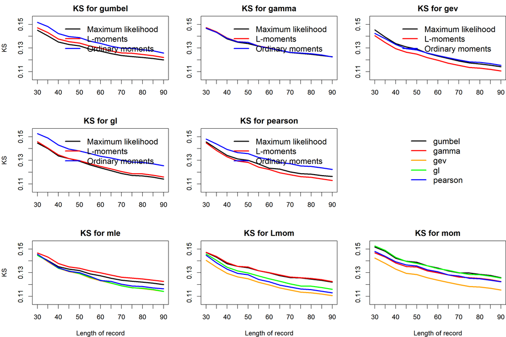

[1] 33 58 64 68 75 78 80 81 82 83 84 85 88 93 94 106 130 [18] 132 134 145 147 156 176 185 220 283 [1] “entered the plotting function” [1] 30 [1] 150

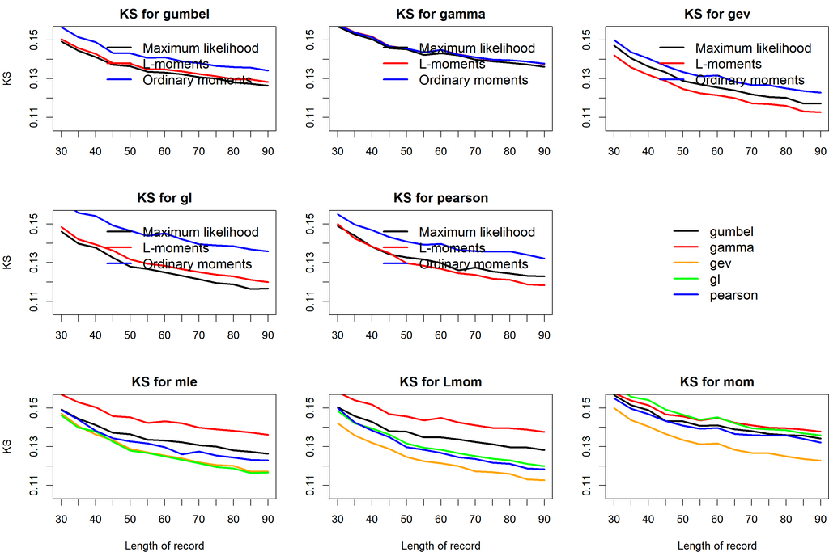

## AD

[1] 1 10 11 12 13 16 17 18 20 21 25 27 34 38 39 40 42 [18] 43 46 49 50 56 57 77 111 116 117 119 121 122 123 124 144 149 [35] 150 152 153 160 161 166 168 174 180 188 189 202 203 208 214 222 224 [52] 229 230 231 233 234 235 237 240 242 244 245 246 247 251 252 254 256 [69] 289 298 [1] “entered the plotting function” [1] 30 [1] 150

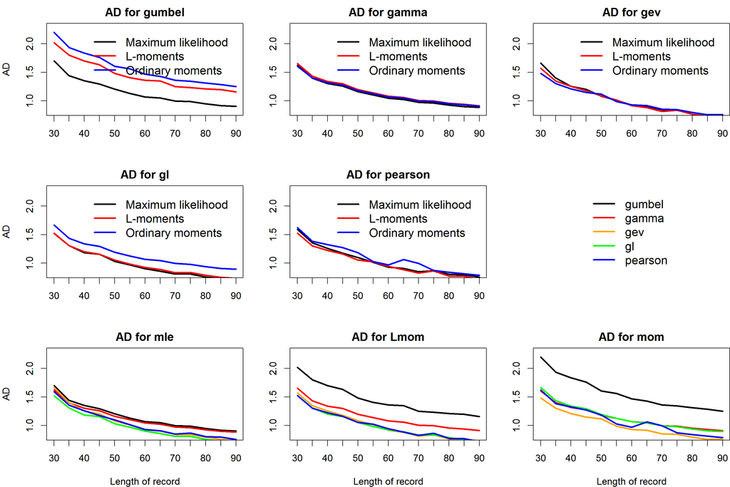

[1] 14 15 19 22 23 28 29 31 32 41 44 45 59 60 61 62 63 [18] 65 66 67 69 74 91 92 96 97 102 103 105 107 108 109 110 112 [35] 120 125 126 127 128 133 136 138 140 141 142 157 163 164 165 171 175 [52] 179 182 197 201 204 216 227 262 279 288 290 291 [1] “entered the plotting function” [1] 30 [1] 150

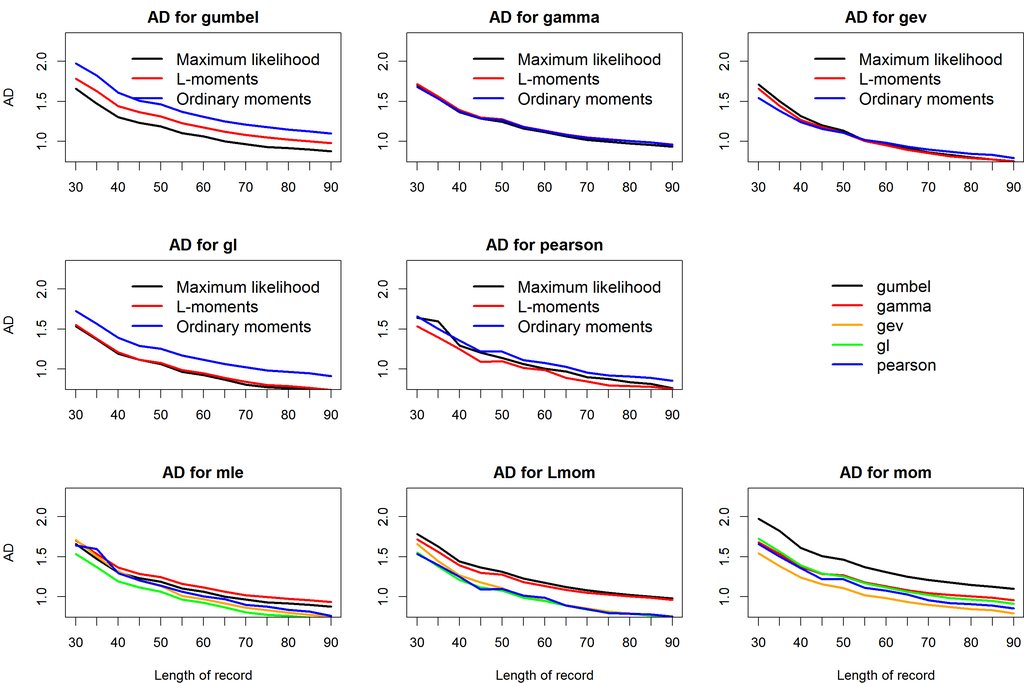

[1] 33 58 64 68 75 78 80 81 82 83 84 85 88 93 94 106 130 [18] 132 134 145 147 156 176 185 220 283 [1] “entered the plotting function” [1] 30 [1] 150

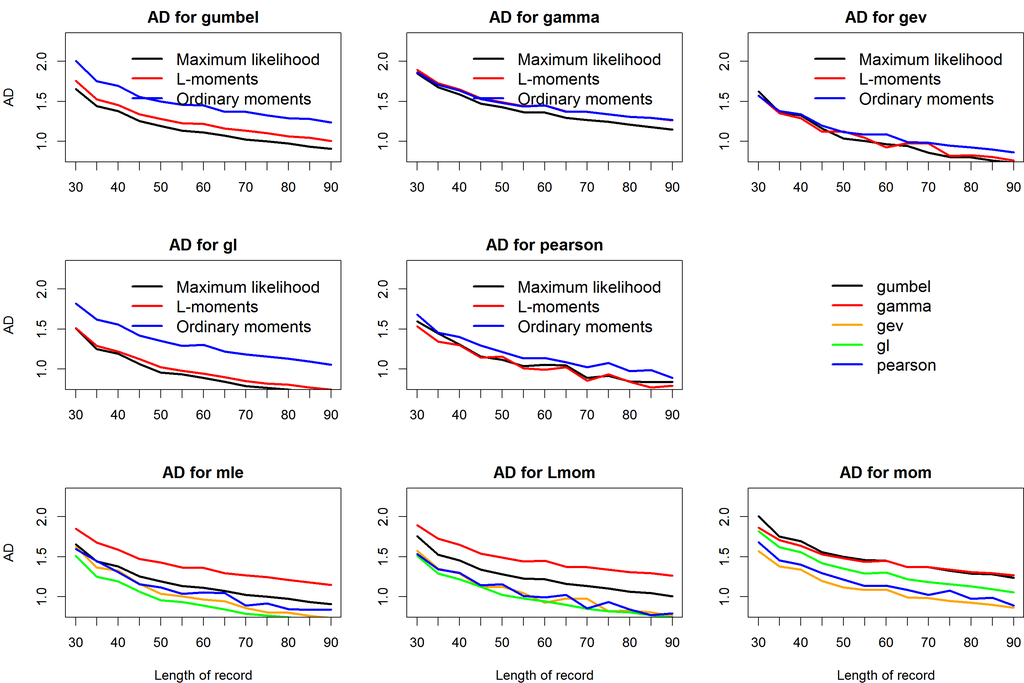